# EDA Results

## 3. Value of the player

### What are the top highest valued players?

**Career values**

- This showcases players who were bought with high-value contracts during their career. It is their total value across seasons, leagues and teams.
- Neymar is the most expensive one. Ronaldo is right behind, but still with more than an 80 million gap. Zlatan is in the fourth place with 163 mil.€ worth of contracts.
- The players started almost always with lower estimation value, eventually having higher actual value. In total, some of them were after multiple transfers valued very highly e.g. Ángel Di Maria, who in total raised his value against estimation up to 1784%.
- The recorder is also James Rodrígues who raised his value against estimation up to 4994% and against actual value still more than 1632%.

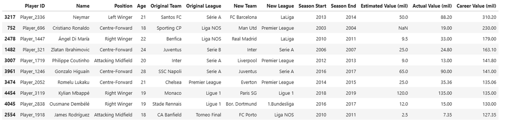

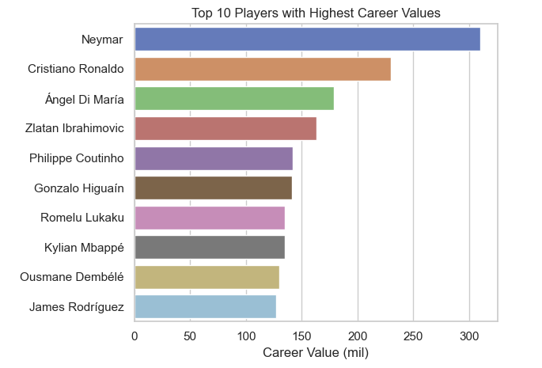

### Which players were traded the most and what is their cumulative price?

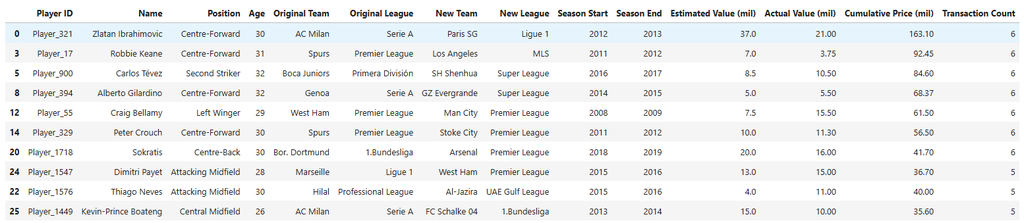

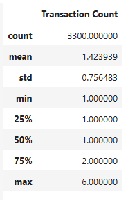

## 4. Position

### Which positions are most valued?

- On average left and right-wingers are the most valued.
- Followed closely with midfield and centre-forward.
- This is also confirmed by the graph "Amount Spent per Player each Season".

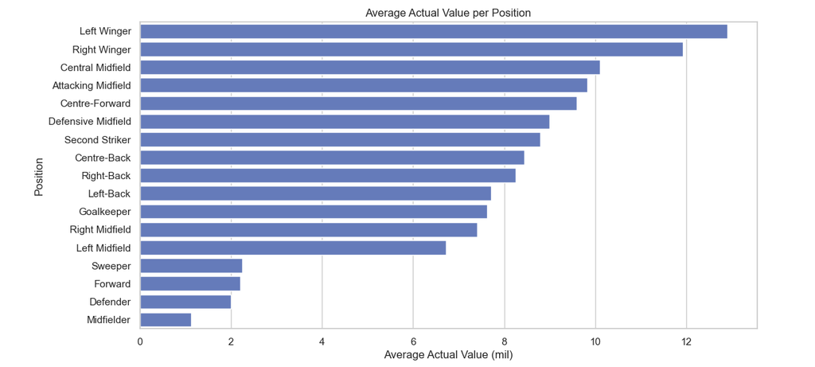

## 5. Characteristics

### What influences player value?

**Correlation insights**

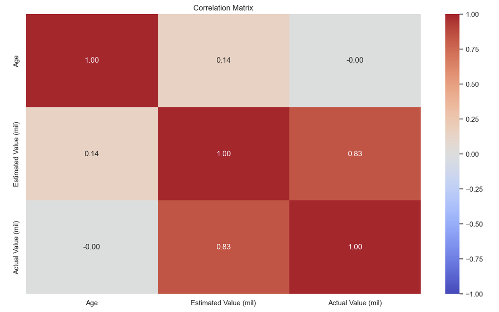

### Age - Average value based on age

**Average Amount spend for Age**

1. Players started to have higher value around age 18-19 years and this continues until 27.
2. After age 27 the average value starts to decrease. This shows that with higher age the value of players goes down (outliers significantly impact the average)..
3. There was a marked difference for players aged 33 years old. After further examination, it was the effect of one outlier **"Cristiano Ronaldo"** who was at the age of 33 sold approximately 9 times above the average value of the player with the price of **117 mil. €**

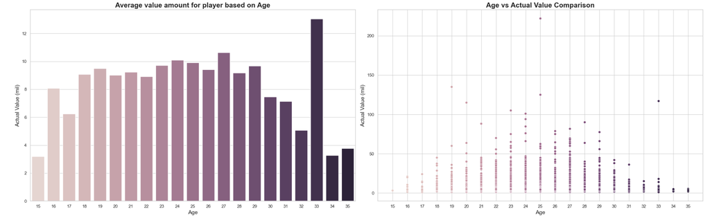